# GGPLOT2: uma introdução à gramática de gráficos

## Estética dos gráficos

### Personalizando o Gráfico com um Tema

- Vamos supor que a resultado estético obtido com os gráficos que obtivemos até agora não seja do seu agrado.
- O fundo cinza não te agrada.
- É muito fácil alterar isso aplicando temas aos nossos gráficos.

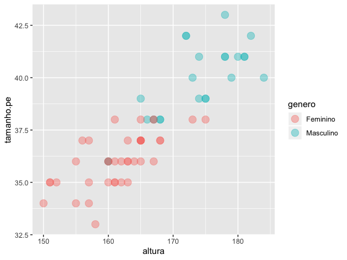

```r
ggplot(linguistas.edit, aes(x = altura, y = tamanho.pe))+
  geom_point(size = 4, alpha = 0.4, aes(color=genero))
```

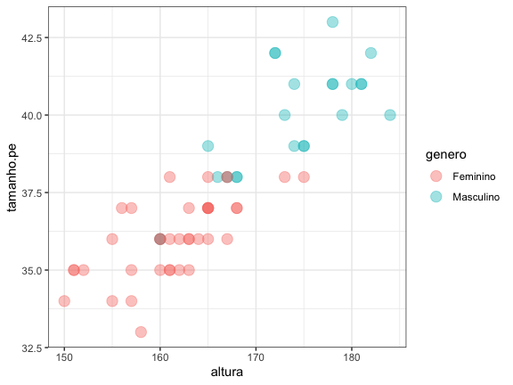

```r
ggplot(linguistas.edit, aes(x = altura, y = tamanho.pe))+
  geom_point(size = 4, alpha = 0.4, aes(color=genero))+
  theme_bw()
```

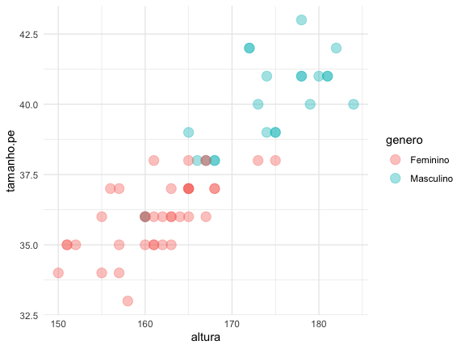

```r
ggplot(linguistas.edit, aes(x = altura, y = tamanho.pe))+
  geom_point(size = 4, alpha = 0.4, aes(color=genero))+
  theme_minimal()
```

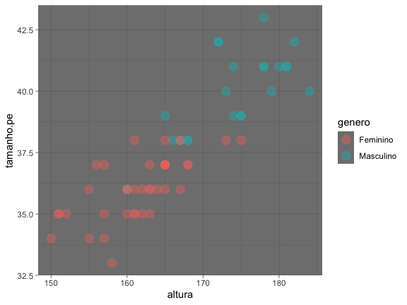

```r
ggplot(linguistas.edit, aes(x = altura, y = tamanho.pe))+
  geom_point(size = 4, alpha = 0.4, aes(color=genero))+
  theme_dark()
```

- Além da personalização do tema do gráfico, é possível alterar a paleta de cores usada em sua construção.

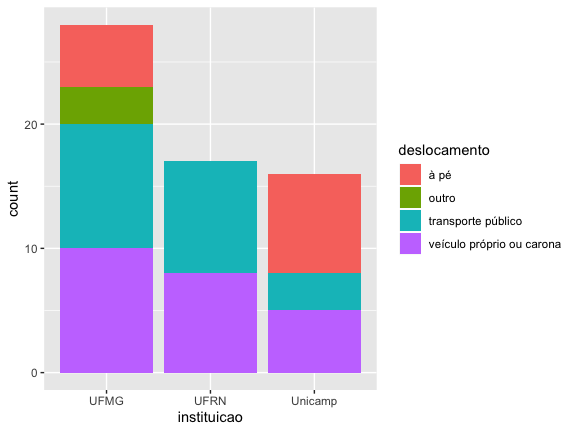

```r
ggplot(linguistas.edit, aes(x = instituicao, fill = deslocamento))+
  geom_bar()
```

- Para gráficos de barra, usamos a função é `scale_fill_brewer`.

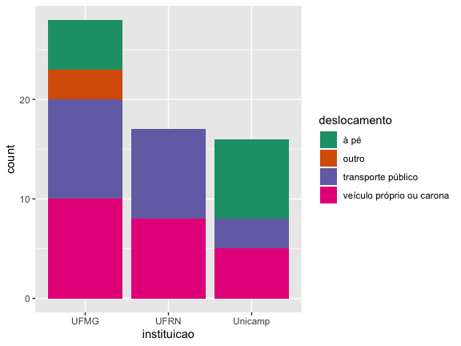

```r
ggplot(linguistas.edit, aes(x = instituicao, fill = deslocamento))+
  geom_bar()+
  scale_fill_brewer(palette = "Dark2")
```

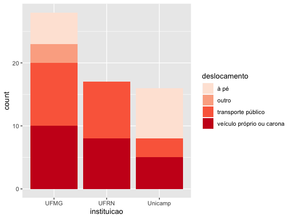

```r
ggplot(linguistas.edit, aes(x = instituicao, fill = deslocamento))+
  geom_bar()+
  scale_fill_brewer(palette = "Reds")
```

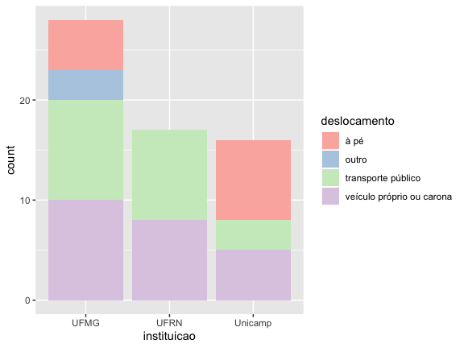

```r
ggplot(linguistas.edit, aes(x = instituicao, fill = deslocamento))+
  geom_bar()+
  scale_fill_brewer(palette = "Pastel1")
```

- Para gráficos de dispersão, usamos a função `scale_colour_brewer`

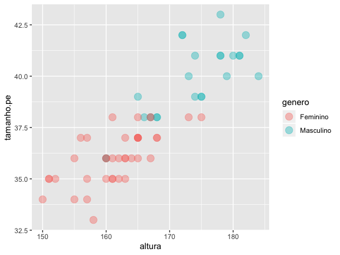

```r
ggplot(linguistas.edit, aes(x = altura, y = tamanho.pe))+
  geom_point(size = 4, alpha = 0.4, aes(color=genero))
```

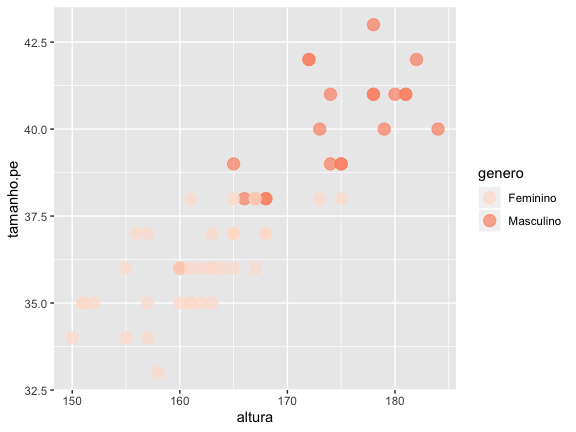

```r
ggplot(linguistas.edit, aes(x = altura, y = tamanho.pe))+
  geom_point(size = 4, alpha = 0.7, aes(color=genero))+
  scale_colour_brewer(palette = "Reds")
```

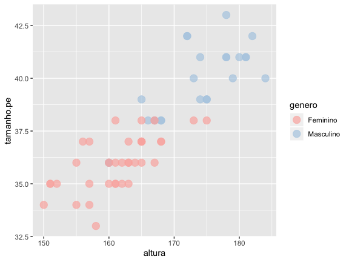

```r
ggplot(linguistas.edit, aes(x = altura, y = tamanho.pe))+
  geom_point(size = 4, alpha = 0.7, aes(color=genero))+
  scale_colour_brewer(palette = "Pastel1")
```

- Como não poderia deixar de ser, é possível combinar temas e paletas em um mesmo gráfico

#### Exercícios

- Utilize o comando `?theme_bw` para encontrar outros temas disponíveis
- Utilize o comando `?scale_colour_brewer` para encontrar outras paletas de cores disponíveis

### Finalização do Gráfico

- Perceba que até o momento não nos precupamos em melhorar a comunicação dos nossos gráficos.
- Nós não alteramos os nomes dos eixos ou colocamos títulos neles.
- Entretanto, é necessário que tenhamos este tipo de cuidado sempre que formos apresentar nossos resultados para outras pessoas.
- Felizmente, a função `labs` permite que resolvamos isso rapidamente:

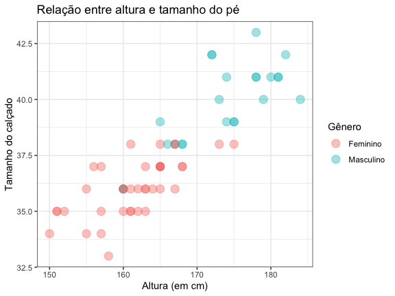

```r
ggplot(linguistas.edit, aes(x = altura, y = tamanho.pe))+
  geom_point(size = 4, alpha = 0.4, aes(color=genero))+
  labs(x = "Altura (em cm)", y = "Tamanho do calçado", color = "Gênero", title = "Relação entre altura e tamanho do pé")+
  theme_bw()
```

- Ao darmos nome à legenda para o gráfico de barra, usamos `fill`

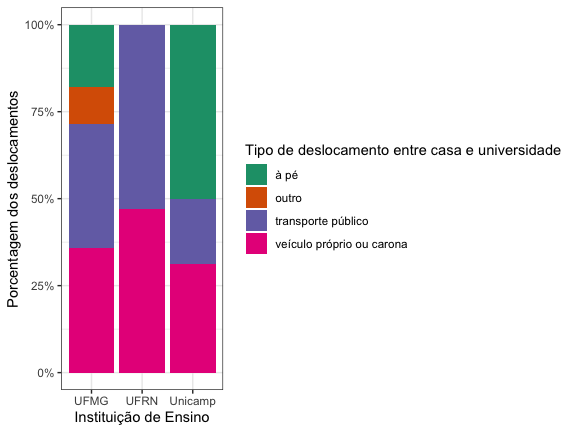

```r
ggplot(linguistas.edit, aes(x = instituicao, fill = deslocamento))+
  geom_bar(aes(y = (..count..)/sum(..count..)), position = "fill")+
  scale_y_continuous(labels=scales::percent)+
  scale_fill_brewer(palette = "Dark2")+
  labs(x = "Instituição de Ensino", y = "Porcentagem dos deslocamentos", fill = "Tipo de deslocamento entre casa e universidade")+
  theme_bw()
```

- Como o título da legenda ficaria muito grande se escrito em uma única linha, fazemos a quebra das linhas com uma barra e a letra *n*.

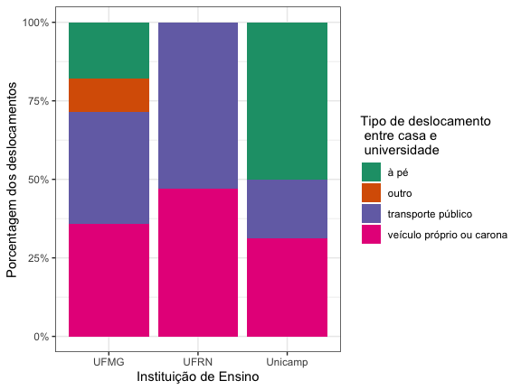

```r
ggplot(linguistas.edit, aes(x = instituicao, fill = deslocamento))+
  geom_bar(aes(y = (..count..)/sum(..count..)), position = "fill")+
  scale_y_continuous(labels=scales::percent)+
  scale_fill_brewer(palette = "Dark2")+
  labs(x = "Instituição de Ensino", y = "Porcentagem dos deslocamentos", fill = "Tipo de deslocamento \n entre casa e \n universidade")+
  theme_bw()
```

## Unindo dplyr e ggplot

- É possível combinar dplyr e ggplot em um único código.
- Imagine que queremos fazer um boxplot de tamanhos de pés apenas dos participantes do gênero masculino, por instituição.
- Primeiro selecionamos esse grupo, e na sequência usamos pipe (`%>%`) para emendar o código do ggplot.
- Note que, nesse caso, na camada `dados`, inserimos um ponto (`.`) para indicar que o conjunto a ser usado é o conjunto selecionado no início do código.

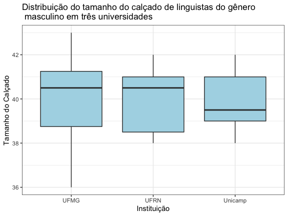

```r
linguistas.edit%>%
  filter(genero=="Masculino")%>%
  ggplot(., aes(x=instituicao, y=tamanho.pe))+
  geom_boxplot(fill = "lightblue")+
  labs(x = "Instituição", y = "Tamanho do Calçado", title  = "Distribuição do tamanho do calçado de linguistas do gênero \n masculino em três universidades")+
  theme_bw()
```

## E Agora? Como Continuar?

- Stack Overflow em Português: https://pt.stackoverflow.com/questions/tagged/r
- Lista Brasileira Oficial de Discussão do Programa R: http://r-br.2285057.n4.nabble.com/
- Google! (ou buscador de sua preferência)